# Risk Factor Analysis

## Outcome Variable

**Outcome Variable:** haz

## Predictor Variables

**Intervention Variable:** hfoodsec

**Adjustment Set:**

- arm
- sex
- W_mage
- meducyrs
- feducyrs
- hhwealth_quart
- vagbrth
- W_nrooms
- W_nchldlt5
- brthmon
- W_parity
- impfloor
- impsan
- safeh20
- delta_W_mage
- delta_meducyrs
- delta_feducyrs
- delta_hhwealth_quart
- delta_vagbrth
- delta_W_nrooms
- delta_W_nchldlt5
- delta_brthmon
- delta_W_parity
- delta_impfloor
- delta_impsan
- delta_safeh20

## Stratifying Variables

The analysis was stratified on these variable(s):

- agecat
- studyid
- country

## Data Summary

| agecat | studyid | country | hfoodsec | n_cell | n |
| --- | --- | --- | --- | --- | --- |
| Birth | ki0047075b-MAL-ED | BANGLADESH | Food Secure | 144 | 172 |
| Birth | ki0047075b-MAL-ED | BANGLADESH | Mildly Food Insecure | 4 | 172 |
| Birth | ki0047075b-MAL-ED | BANGLADESH | Food Insecure | 24 | 172 |
| Birth | ki0047075b-MAL-ED | BRAZIL | Food Secure | 0 | 28 |
| Birth | ki0047075b-MAL-ED | BRAZIL | Mildly Food Insecure | 4 | 28 |
| Birth | ki0047075b-MAL-ED | BRAZIL | Food Insecure | 24 | 28 |
| Birth | ki0047075b-MAL-ED | INDIA | Food Secure | 34 | 37 |
| Birth | ki0047075b-MAL-ED | INDIA | Mildly Food Insecure | 1 | 37 |
| Birth | ki0047075b-MAL-ED | INDIA | Food Insecure | 2 | 37 |
| Birth | ki0047075b-MAL-ED | NEPAL | Food Secure | 10 | 14 |
| Birth | ki0047075b-MAL-ED | NEPAL | Mildly Food Insecure | 1 | 14 |
| Birth | ki0047075b-MAL-ED | NEPAL | Food Insecure | 3 | 14 |
| Birth | ki0047075b-MAL-ED | PERU | Food Secure | 24 | 91 |
| Birth | ki0047075b-MAL-ED | PERU | Mildly Food Insecure | 23 | 91 |
| Birth | ki0047075b-MAL-ED | PERU | Food Insecure | 44 | 91 |
| Birth | ki0047075b-MAL-ED | SOUTH AFRICA | Food Secure | 45 | 88 |
| Birth | ki0047075b-MAL-ED | SOUTH AFRICA | Mildly Food Insecure | 9 | 88 |
| Birth | ki0047075b-MAL-ED | SOUTH AFRICA | Food Insecure | 34 | 88 |
| Birth | ki1017093-NIH-Birth | BANGLADESH | Food Secure | 90 | 608 |
| Birth | ki1017093-NIH-Birth | BANGLADESH | Mildly Food Insecure | 478 | 608 |
| Birth | ki1017093-NIH-Birth | BANGLADESH | Food Insecure | 40 | 608 |
| Birth | ki1017093c-NIH-Crypto | BANGLADESH | Food Secure | 439 | 732 |
| Birth | ki1017093c-NIH-Crypto | BANGLADESH | Mildly Food Insecure | 209 | 732 |
| Birth | ki1017093c-NIH-Crypto | BANGLADESH | Food Insecure | 84 | 732 |
| Birth | ki1113344-GMS-Nepal | NEPAL | Food Secure | 477 | 672 |
| Birth | ki1113344-GMS-Nepal | NEPAL | Mildly Food Insecure | 106 | 672 |
| Birth | ki1113344-GMS-Nepal | NEPAL | Food Insecure | 89 | 672 |
| Birth | kiGH5241-JiVitA-3 | BANGLADESH | Food Secure | 6951 | 14364 |
| Birth | kiGH5241-JiVitA-3 | BANGLADESH | Mildly Food Insecure | 4877 | 14364 |
| Birth | kiGH5241-JiVitA-3 | BANGLADESH | Food Insecure | 2536 | 14364 |

[output cut: 69 more lines]

The following strata were considered:

- agecat: 24 months, studyid: ki0047075b-MAL-ED, country: BANGLADESH
- agecat: 24 months, studyid: ki0047075b-MAL-ED, country: BRAZIL
- agecat: 24 months, studyid: ki0047075b-MAL-ED, country: INDIA
- agecat: 24 months, studyid: ki0047075b-MAL-ED, country: NEPAL
- agecat: 24 months, studyid: ki0047075b-MAL-ED, country: PERU
- agecat: 24 months, studyid: ki0047075b-MAL-ED, country: SOUTH AFRICA
- agecat: 24 months, studyid: ki1017093-NIH-Birth, country: BANGLADESH
- agecat: 24 months, studyid: ki1017093c-NIH-Crypto, country: BANGLADESH
- agecat: 24 months, studyid: ki1113344-GMS-Nepal, country: NEPAL
- agecat: 24 months, studyid: kiGH5241-JiVitA-3, country: BANGLADESH
- agecat: 24 months, studyid: kiGH5241-JiVitA-4, country: BANGLADESH
- agecat: 6 months, studyid: ki0047075b-MAL-ED, country: BANGLADESH
- agecat: 6 months, studyid: ki0047075b-MAL-ED, country: BRAZIL
- agecat: 6 months, studyid: ki0047075b-MAL-ED, country: INDIA
- agecat: 6 months, studyid: ki0047075b-MAL-ED, country: NEPAL
- agecat: 6 months, studyid: ki0047075b-MAL-ED, country: PERU
- agecat: 6 months, studyid: ki0047075b-MAL-ED, country: SOUTH AFRICA
- agecat: 6 months, studyid: ki1017093-NIH-Birth, country: BANGLADESH
- agecat: 6 months, studyid: ki1017093c-NIH-Crypto, country: BANGLADESH
- agecat: 6 months, studyid: ki1113344-GMS-Nepal, country: NEPAL
- agecat: 6 months, studyid: kiGH5241-JiVitA-3, country: BANGLADESH
- agecat: 6 months, studyid: kiGH5241-JiVitA-4, country: BANGLADESH
- agecat: Birth, studyid: ki0047075b-MAL-ED, country: BANGLADESH
- agecat: Birth, studyid: ki0047075b-MAL-ED, country: BRAZIL
- agecat: Birth, studyid: ki0047075b-MAL-ED, country: INDIA
- agecat: Birth, studyid: ki0047075b-MAL-ED, country: NEPAL
- agecat: Birth, studyid: ki0047075b-MAL-ED, country: PERU
- agecat: Birth, studyid: ki0047075b-MAL-ED, country: SOUTH AFRICA
- agecat: Birth, studyid: ki1017093-NIH-Birth, country: BANGLADESH
- agecat: Birth, studyid: ki1017093c-NIH-Crypto, country: BANGLADESH
- agecat: Birth, studyid: ki1113344-GMS-Nepal, country: NEPAL
- agecat: Birth, studyid: kiGH5241-JiVitA-3, country: BANGLADESH
- agecat: Birth, studyid: kiGH5241-JiVitA-4, country: BANGLADESH

### Dropped Strata

Some strata were dropped due to rare outcomes:

- agecat: Birth, studyid: ki0047075b-MAL-ED, country: BANGLADESH
- agecat: Birth, studyid: ki0047075b-MAL-ED, country: BRAZIL
- agecat: Birth, studyid: ki0047075b-MAL-ED, country: INDIA
- agecat: Birth, studyid: ki0047075b-MAL-ED, country: NEPAL
- agecat: 6 months, studyid: ki0047075b-MAL-ED, country: BANGLADESH
- agecat: 6 months, studyid: ki0047075b-MAL-ED, country: BRAZIL
- agecat: 24 months, studyid: ki0047075b-MAL-ED, country: BANGLADESH
- agecat: 24 months, studyid: ki0047075b-MAL-ED, country: BRAZIL

## Methods Detail

We’re interested in the causal parameters $E[Y_a]$ for all values of $a \in \mathcal{A}$. These parameters represent the mean outcome if, possibly contrary to fact, we intervened to set all units to have $A=a$. Under the randomization and positivity assumptions, these are identified by the statistical parameters $\psi_a=E_W[E_{Y|A,W}(Y|A=a,W)]$. In addition, we’re interested in the mean of $Y$, $E[Y]$ under no intervention (the observed mean). We will estimate these parameters by using SuperLearner to fit the relevant likelihood factors – $E_{Y|A,W}(Y|A=a,W)$ and $p(A=a|W)$, and then updating our likelihood fit using a joint TMLE.

For unadjusted analyses ($W=\{\}$), initial likelihoods were estimated using Lrnr_glm to estimate the simple $E(Y|A)$ and Lrnr_mean to estimate $p(A)$. For adjusted analyses, a small library containing Lrnr_glmnet, Lrnr_xgboost, and Lrnr_mean was used.

Having estimated these parameters, we will then use the delta method to estimate relative risks and attributable risks relative to a prespecified baseline level of $A$.

# Results Detail

## Results Plots

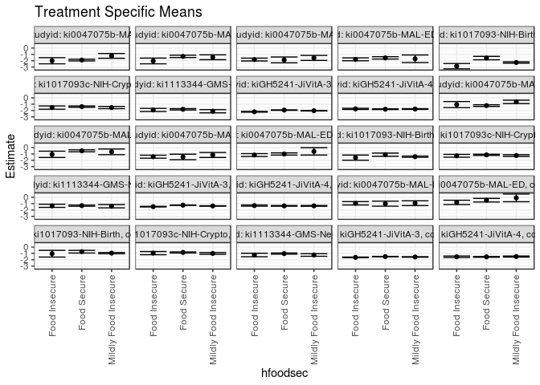

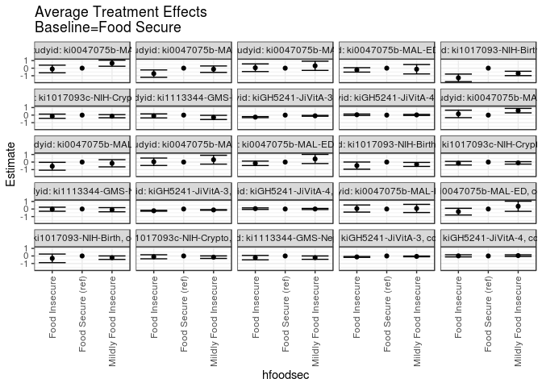

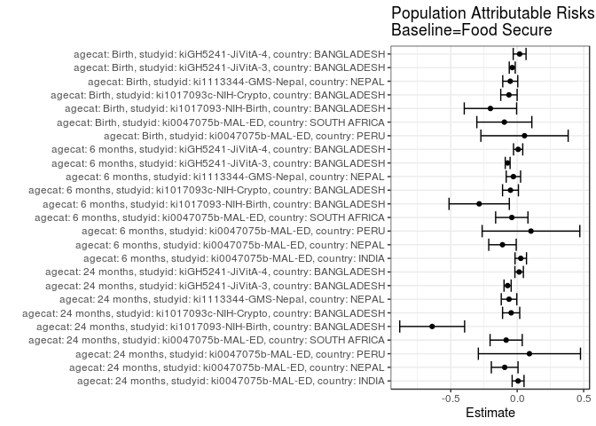

## Results Table

### Parameter: TSM

| agecat | studyid | country | intervention_level | baseline_level | estimate | ci_lower | ci_upper |
| --- | --- | --- | --- | --- | --- | --- | --- |
| Birth | ki0047075b-MAL-ED | PERU | Food Secure | NA | -1.0040648 | -1.3971000 | -0.6110297 |
| Birth | ki0047075b-MAL-ED | PERU | Mildly Food Insecure | NA | -0.9281548 | -1.3040326 | -0.5522770 |
| Birth | ki0047075b-MAL-ED | PERU | Food Insecure | NA | -0.9426302 | -1.2050200 | -0.6802403 |
| Birth | ki0047075b-MAL-ED | SOUTH AFRICA | Food Secure | NA | -0.4535556 | -0.7370575 | -0.1700536 |
| Birth | ki0047075b-MAL-ED | SOUTH AFRICA | Mildly Food Insecure | NA | -0.0888889 | -0.6955550 | 0.5177773 |
| Birth | ki0047075b-MAL-ED | SOUTH AFRICA | Food Insecure | NA | -0.8005882 | -1.1433809 | -0.4577955 |
| Birth | ki1017093-NIH-Birth | BANGLADESH | Food Secure | NA | -0.7297070 | -0.9374553 | -0.5219587 |
| Birth | ki1017093-NIH-Birth | BANGLADESH | Mildly Food Insecure | NA | -0.9556976 | -1.0548517 | -0.8565435 |
| Birth | ki1017093-NIH-Birth | BANGLADESH | Food Insecure | NA | -1.0469640 | -1.5745056 | -0.5194224 |
| Birth | ki1017093c-NIH-Crypto | BANGLADESH | Food Secure | NA | -0.8473350 | -0.9369559 | -0.7577140 |
| Birth | ki1017093c-NIH-Crypto | BANGLADESH | Mildly Food Insecure | NA | -1.0065088 | -1.1474710 | -0.8655465 |
| Birth | ki1017093c-NIH-Crypto | BANGLADESH | Food Insecure | NA | -0.9550922 | -1.2059293 | -0.7042551 |
| Birth | ki1113344-GMS-Nepal | NEPAL | Food Secure | NA | -1.0269247 | -1.1243660 | -0.9294834 |
| Birth | ki1113344-GMS-Nepal | NEPAL | Mildly Food Insecure | NA | -1.2478902 | -1.4474770 | -1.0483034 |
| Birth | ki1113344-GMS-Nepal | NEPAL | Food Insecure | NA | -1.2504129 | -1.5262451 | -0.9745808 |
| Birth | kiGH5241-JiVitA-3 | BANGLADESH | Food Secure | NA | -1.5001745 | -1.5310201 | -1.4693289 |
| Birth | kiGH5241-JiVitA-3 | BANGLADESH | Mildly Food Insecure | NA | -1.5592800 | -1.5988069 | -1.5197530 |
| Birth | kiGH5241-JiVitA-3 | BANGLADESH | Food Insecure | NA | -1.6272882 | -1.6789635 | -1.5756130 |
| Birth | kiGH5241-JiVitA-4 | BANGLADESH | Food Secure | NA | -1.5431940 | -1.6113450 | -1.4750430 |
| Birth | kiGH5241-JiVitA-4 | BANGLADESH | Mildly Food Insecure | NA | -1.4971624 | -1.5829255 | -1.4113993 |
| Birth | kiGH5241-JiVitA-4 | BANGLADESH | Food Insecure | NA | -1.5304659 | -1.6501366 | -1.4107951 |
| 6 months | ki0047075b-MAL-ED | INDIA | Food Secure | NA | -1.2287544 | -1.3589893 | -1.0985195 |
| 6 months | ki0047075b-MAL-ED | INDIA | Mildly Food Insecure | NA | -0.6360000 | -0.9019405 | -0.3700595 |
| 6 months | ki0047075b-MAL-ED | INDIA | Food Insecure | NA | -1.0694118 | -1.5456747 | -0.5931488 |
| 6 months | ki0047075b-MAL-ED | NEPAL | Food Secure | NA | -0.5155629 | -0.6754236 | -0.3557021 |
| 6 months | ki0047075b-MAL-ED | NEPAL | Mildly Food Insecure | NA | -0.6740228 | -1.1213446 | -0.2267009 |
| 6 months | ki0047075b-MAL-ED | NEPAL | Food Insecure | NA | -1.0700538 | -1.5643944 | -0.5757132 |
| 6 months | ki0047075b-MAL-ED | PERU | Food Secure | NA | -1.4819680 | -1.9142633 | -1.0496728 |
| 6 months | ki0047075b-MAL-ED | PERU | Mildly Food Insecure | NA | -1.1703731 | -1.5635845 | -0.7771617 |
| 6 months | ki0047075b-MAL-ED | PERU | Food Insecure | NA | -1.4421231 | -1.6786736 | -1.2055726 |
| 6 months | ki0047075b-MAL-ED | SOUTH AFRICA | Food Secure | NA | -1.0132571 | -1.1886505 | -0.8378637 |
| 6 months | ki0047075b-MAL-ED | SOUTH AFRICA | Mildly Food Insecure | NA | -0.6024465 | -1.1831317 | -0.0217614 |
| 6 months | ki0047075b-MAL-ED | SOUTH AFRICA | Food Insecure | NA | -1.1798707 | -1.4087744 | -0.9509670 |
| 6 months | ki1017093-NIH-Birth | BANGLADESH | Food Secure | NA | -1.1214311 | -1.3698708 | -0.8729914 |
| 6 months | ki1017093-NIH-Birth | BANGLADESH | Mildly Food Insecure | NA | -1.4350248 | -1.5311671 | -1.3388825 |
| 6 months | ki1017093-NIH-Birth | BANGLADESH | Food Insecure | NA | -1.5904160 | -1.9955055 | -1.1853266 |
| 6 months | ki1017093c-NIH-Crypto | BANGLADESH | Food Secure | NA | -1.1481280 | -1.2408690 | -1.0553869 |
| 6 months | ki1017093c-NIH-Crypto | BANGLADESH | Mildly Food Insecure | NA | -1.2571809 | -1.3939342 | -1.1204276 |
| 6 months | ki1017093c-NIH-Crypto | BANGLADESH | Food Insecure | NA | -1.2978174 | -1.5167197 | -1.0789150 |
| 6 months | ki1113344-GMS-Nepal | NEPAL | Food Secure | NA | -1.3135291 | -1.4111680 | -1.2158902 |
| 6 months | ki1113344-GMS-Nepal | NEPAL | Mildly Food Insecure | NA | -1.4057534 | -1.6647530 | -1.1467538 |
| 6 months | ki1113344-GMS-Nepal | NEPAL | Food Insecure | NA | -1.3418829 | -1.5898116 | -1.0939542 |
| 6 months | kiGH5241-JiVitA-3 | BANGLADESH | Food Secure | NA | -1.2413630 | -1.2703849 | -1.2123412 |
| 6 months | kiGH5241-JiVitA-3 | BANGLADESH | Mildly Food Insecure | NA | -1.3627677 | -1.3947463 | -1.3307891 |
| 6 months | kiGH5241-JiVitA-3 | BANGLADESH | Food Insecure | NA | -1.4718066 | -1.5244183 | -1.4191950 |
| 6 months | kiGH5241-JiVitA-4 | BANGLADESH | Food Secure | NA | -1.3517482 | -1.4038099 | -1.2996864 |
| 6 months | kiGH5241-JiVitA-4 | BANGLADESH | Mildly Food Insecure | NA | -1.3482130 | -1.4077691 | -1.2886568 |
| 6 months | kiGH5241-JiVitA-4 | BANGLADESH | Food Insecure | NA | -1.3037194 | -1.3930733 | -1.2143654 |
| 24 months | ki0047075b-MAL-ED | INDIA | Food Secure | NA | -1.8935000 | -2.0301943 | -1.7568057 |
| 24 months | ki0047075b-MAL-ED | INDIA | Mildly Food Insecure | NA | -1.2370000 | -1.6132318 | -0.8607682 |
| 24 months | ki0047075b-MAL-ED | INDIA | Food Insecure | NA | -2.0035294 | -2.4884028 | -1.5186561 |
| 24 months | ki0047075b-MAL-ED | NEPAL | Food Secure | NA | -1.3149995 | -1.4999837 | -1.1300153 |
| 24 months | ki0047075b-MAL-ED | NEPAL | Mildly Food Insecure | NA | -1.4498556 | -1.8315372 | -1.0681740 |
| 24 months | ki0047075b-MAL-ED | NEPAL | Food Insecure | NA | -2.0373448 | -2.4859526 | -1.5887369 |
| 24 months | ki0047075b-MAL-ED | PERU | Food Secure | NA | -1.8702521 | -2.3281832 | -1.4123210 |
| 24 months | ki0047075b-MAL-ED | PERU | Mildly Food Insecure | NA | -1.5548441 | -1.9463497 | -1.1633386 |
| 24 months | ki0047075b-MAL-ED | PERU | Food Insecure | NA | -1.8142188 | -2.0348637 | -1.5935739 |
| 24 months | ki0047075b-MAL-ED | SOUTH AFRICA | Food Secure | NA | -1.5500520 | -1.7331166 | -1.3669875 |
| 24 months | ki0047075b-MAL-ED | SOUTH AFRICA | Mildly Food Insecure | NA | -1.6873747 | -2.2824822 | -1.0922672 |
| 24 months | ki0047075b-MAL-ED | SOUTH AFRICA | Food Insecure | NA | -1.7792173 | -2.0054297 | -1.5530049 |
| 24 months | ki1017093-NIH-Birth | BANGLADESH | Food Secure | NA | -1.5794684 | -1.8472348 | -1.3117019 |
| 24 months | ki1017093-NIH-Birth | BANGLADESH | Mildly Food Insecure | NA | -2.2763963 | -2.3845248 | -2.1682677 |
| 24 months | ki1017093-NIH-Birth | BANGLADESH | Food Insecure | NA | -2.8580583 | -3.2782085 | -2.4379081 |
| 24 months | ki1017093c-NIH-Crypto | BANGLADESH | Food Secure | NA | -1.3956741 | -1.5023568 | -1.2889915 |
| 24 months | ki1017093c-NIH-Crypto | BANGLADESH | Mildly Food Insecure | NA | -1.5384668 | -1.7172252 | -1.3597085 |
| 24 months | ki1017093c-NIH-Crypto | BANGLADESH | Food Insecure | NA | -1.5407556 | -1.7986178 | -1.2828934 |
| 24 months | ki1113344-GMS-Nepal | NEPAL | Food Secure | NA | -1.8143900 | -1.9171679 | -1.7116121 |
| 24 months | ki1113344-GMS-Nepal | NEPAL | Mildly Food Insecure | NA | -2.1158689 | -2.3717388 | -1.8599991 |
| 24 months | ki1113344-GMS-Nepal | NEPAL | Food Insecure | NA | -1.9179336 | -2.1630431 | -1.6728240 |
| 24 months | kiGH5241-JiVitA-3 | BANGLADESH | Food Secure | NA | -1.9377553 | -1.9767010 | -1.8988095 |
| 24 months | kiGH5241-JiVitA-3 | BANGLADESH | Mildly Food Insecure | NA | -2.0312279 | -2.0755195 | -1.9869363 |
| 24 months | kiGH5241-JiVitA-3 | BANGLADESH | Food Insecure | NA | -2.2018494 | -2.2618780 | -2.1418209 |
| 24 months | kiGH5241-JiVitA-4 | BANGLADESH | Food Secure | NA | -1.7947435 | -1.8440124 | -1.7454746 |
| 24 months | kiGH5241-JiVitA-4 | BANGLADESH | Mildly Food Insecure | NA | -1.7688510 | -1.8238803 | -1.7138217 |
| 24 months | kiGH5241-JiVitA-4 | BANGLADESH | Food Insecure | NA | -1.7464780 | -1.8330940 | -1.6598620 |

### Parameter: E(Y)

| agecat | studyid | country | intervention_level | baseline_level | estimate | ci_lower | ci_upper |
| --- | --- | --- | --- | --- | --- | --- | --- |
| Birth | ki0047075b-MAL-ED | PERU | NA | NA | -0.9490110 | -1.1400314 | -0.7579906 |
| Birth | ki0047075b-MAL-ED | SOUTH AFRICA | NA | NA | -0.5503409 | -0.7616444 | -0.3390374 |
| Birth | ki1017093-NIH-Birth | BANGLADESH | NA | NA | -0.9310197 | -1.0197391 | -0.8423003 |
| Birth | ki1017093c-NIH-Crypto | BANGLADESH | NA | NA | -0.9094945 | -0.9809370 | -0.8380521 |
| Birth | ki1113344-GMS-Nepal | NEPAL | NA | NA | -1.0791964 | -1.1604792 | -0.9979137 |
| Birth | kiGH5241-JiVitA-3 | BANGLADESH | NA | NA | -1.5375132 | -1.5596692 | -1.5153573 |
| Birth | kiGH5241-JiVitA-4 | BANGLADESH | NA | NA | -1.5248719 | -1.5743851 | -1.4753587 |
| 6 months | ki0047075b-MAL-ED | INDIA | NA | NA | -1.2019969 | -1.3256948 | -1.0782989 |
| 6 months | ki0047075b-MAL-ED | NEPAL | NA | NA | -0.6262760 | -0.7758267 | -0.4767254 |
| 6 months | ki0047075b-MAL-ED | PERU | NA | NA | -1.3783784 | -1.5611768 | -1.1955799 |
| 6 months | ki0047075b-MAL-ED | SOUTH AFRICA | NA | NA | -1.0539254 | -1.1902766 | -0.9175743 |
| 6 months | ki1017093-NIH-Birth | BANGLADESH | NA | NA | -1.4073821 | -1.4960598 | -1.3187043 |
| 6 months | ki1017093c-NIH-Crypto | BANGLADESH | NA | NA | -1.1986783 | -1.2700937 | -1.1272630 |
| 6 months | ki1113344-GMS-Nepal | NEPAL | NA | NA | -1.3421764 | -1.4201083 | -1.2642445 |
| 6 months | kiGH5241-JiVitA-3 | BANGLADESH | NA | NA | -1.3131326 | -1.3362851 | -1.2899801 |
| 6 months | kiGH5241-JiVitA-4 | BANGLADESH | NA | NA | -1.3446891 | -1.3822219 | -1.3071564 |
| 24 months | ki0047075b-MAL-ED | INDIA | NA | NA | -1.8868396 | -2.0164954 | -1.7571839 |
| 24 months | ki0047075b-MAL-ED | NEPAL | NA | NA | -1.4092187 | -1.5701249 | -1.2483126 |
| 24 months | ki0047075b-MAL-ED | PERU | NA | NA | -1.7783956 | -1.9536701 | -1.6031212 |
| 24 months | ki0047075b-MAL-ED | SOUTH AFRICA | NA | NA | -1.6331323 | -1.7704624 | -1.4958022 |
| 24 months | ki1017093-NIH-Birth | BANGLADESH | NA | NA | -2.2190579 | -2.3217459 | -2.1163699 |
| 24 months | ki1017093c-NIH-Crypto | BANGLADESH | NA | NA | -1.4412646 | -1.5249156 | -1.3576135 |
| 24 months | ki1113344-GMS-Nepal | NEPAL | NA | NA | -1.8758368 | -1.9623349 | -1.7893388 |
| 24 months | kiGH5241-JiVitA-3 | BANGLADESH | NA | NA | -2.0099416 | -2.0377955 | -1.9820876 |
| 24 months | kiGH5241-JiVitA-4 | BANGLADESH | NA | NA | -1.7801485 | -1.8158427 | -1.7444543 |

### Parameter: ATE

| agecat | studyid | country | intervention_level | baseline_level | estimate | ci_lower | ci_upper |
| --- | --- | --- | --- | --- | --- | --- | --- |
| Birth | ki0047075b-MAL-ED | PERU | Food Secure | Food Secure | 0.0000000 | 0.0000000 | 0.0000000 |
| Birth | ki0047075b-MAL-ED | PERU | Mildly Food Insecure | Food Secure | 0.0759101 | -0.4647632 | 0.6165834 |
| Birth | ki0047075b-MAL-ED | PERU | Food Insecure | Food Secure | 0.0614347 | -0.4088841 | 0.5317535 |
| Birth | ki0047075b-MAL-ED | SOUTH AFRICA | Food Secure | Food Secure | 0.0000000 | 0.0000000 | 0.0000000 |
| Birth | ki0047075b-MAL-ED | SOUTH AFRICA | Mildly Food Insecure | Food Secure | 0.3646667 | -0.3049729 | 1.0343063 |
| Birth | ki0047075b-MAL-ED | SOUTH AFRICA | Food Insecure | Food Secure | -0.3470327 | -0.7918699 | 0.0978046 |
| Birth | ki1017093-NIH-Birth | BANGLADESH | Food Secure | Food Secure | 0.0000000 | 0.0000000 | 0.0000000 |
| Birth | ki1017093-NIH-Birth | BANGLADESH | Mildly Food Insecure | Food Secure | -0.2259906 | -0.4565860 | 0.0046049 |
| Birth | ki1017093-NIH-Birth | BANGLADESH | Food Insecure | Food Secure | -0.3172570 | -0.8857423 | 0.2512283 |
| Birth | ki1017093c-NIH-Crypto | BANGLADESH | Food Secure | Food Secure | 0.0000000 | 0.0000000 | 0.0000000 |
| Birth | ki1017093c-NIH-Crypto | BANGLADESH | Mildly Food Insecure | Food Secure | -0.1591738 | -0.3265739 | 0.0082262 |
| Birth | ki1017093c-NIH-Crypto | BANGLADESH | Food Insecure | Food Secure | -0.1077572 | -0.3743823 | 0.1588678 |
| Birth | ki1113344-GMS-Nepal | NEPAL | Food Secure | Food Secure | 0.0000000 | 0.0000000 | 0.0000000 |
| Birth | ki1113344-GMS-Nepal | NEPAL | Mildly Food Insecure | Food Secure | -0.2209655 | -0.4427624 | 0.0008314 |
| Birth | ki1113344-GMS-Nepal | NEPAL | Food Insecure | Food Secure | -0.2234882 | -0.5154099 | 0.0684334 |
| Birth | kiGH5241-JiVitA-3 | BANGLADESH | Food Secure | Food Secure | 0.0000000 | 0.0000000 | 0.0000000 |
| Birth | kiGH5241-JiVitA-3 | BANGLADESH | Mildly Food Insecure | Food Secure | -0.0591054 | -0.1071469 | -0.0110640 |
| Birth | kiGH5241-JiVitA-3 | BANGLADESH | Food Insecure | Food Secure | -0.1271137 | -0.1859428 | -0.0682846 |
| Birth | kiGH5241-JiVitA-4 | BANGLADESH | Food Secure | Food Secure | 0.0000000 | 0.0000000 | 0.0000000 |
| Birth | kiGH5241-JiVitA-4 | BANGLADESH | Mildly Food Insecure | Food Secure | 0.0460316 | -0.0628438 | 0.1549070 |
| Birth | kiGH5241-JiVitA-4 | BANGLADESH | Food Insecure | Food Secure | 0.0127281 | -0.1255038 | 0.1509600 |
| 6 months | ki0047075b-MAL-ED | INDIA | Food Secure | Food Secure | 0.0000000 | 0.0000000 | 0.0000000 |
| 6 months | ki0047075b-MAL-ED | INDIA | Mildly Food Insecure | Food Secure | 0.5927544 | 0.2966371 | 0.8888717 |
| 6 months | ki0047075b-MAL-ED | INDIA | Food Insecure | Food Secure | 0.1593426 | -0.3344058 | 0.6530910 |
| 6 months | ki0047075b-MAL-ED | NEPAL | Food Secure | Food Secure | 0.0000000 | 0.0000000 | 0.0000000 |
| 6 months | ki0047075b-MAL-ED | NEPAL | Mildly Food Insecure | Food Secure | -0.1584599 | -0.6340995 | 0.3171797 |
| 6 months | ki0047075b-MAL-ED | NEPAL | Food Insecure | Food Secure | -0.5544909 | -1.0739894 | -0.0349924 |
| 6 months | ki0047075b-MAL-ED | PERU | Food Secure | Food Secure | 0.0000000 | 0.0000000 | 0.0000000 |
| 6 months | ki0047075b-MAL-ED | PERU | Mildly Food Insecure | Food Secure | 0.3115949 | -0.2747933 | 0.8979831 |
| 6 months | ki0047075b-MAL-ED | PERU | Food Insecure | Food Secure | 0.0398450 | -0.4527110 | 0.5324009 |
| 6 months | ki0047075b-MAL-ED | SOUTH AFRICA | Food Secure | Food Secure | 0.0000000 | 0.0000000 | 0.0000000 |
| 6 months | ki0047075b-MAL-ED | SOUTH AFRICA | Mildly Food Insecure | Food Secure | 0.4108106 | -0.1955936 | 1.0172147 |
| 6 months | ki0047075b-MAL-ED | SOUTH AFRICA | Food Insecure | Food Secure | -0.1666136 | -0.4562286 | 0.1230014 |
| 6 months | ki1017093-NIH-Birth | BANGLADESH | Food Secure | Food Secure | 0.0000000 | 0.0000000 | 0.0000000 |
| 6 months | ki1017093-NIH-Birth | BANGLADESH | Mildly Food Insecure | Food Secure | -0.3135937 | -0.5801712 | -0.0470163 |
| 6 months | ki1017093-NIH-Birth | BANGLADESH | Food Insecure | Food Secure | -0.4689849 | -0.9445106 | 0.0065408 |
| 6 months | ki1017093c-NIH-Crypto | BANGLADESH | Food Secure | Food Secure | 0.0000000 | 0.0000000 | 0.0000000 |
| 6 months | ki1017093c-NIH-Crypto | BANGLADESH | Mildly Food Insecure | Food Secure | -0.1090530 | -0.2743272 | 0.0562213 |
| 6 months | ki1017093c-NIH-Crypto | BANGLADESH | Food Insecure | Food Secure | -0.1496894 | -0.3876025 | 0.0882237 |
| 6 months | ki1113344-GMS-Nepal | NEPAL | Food Secure | Food Secure | 0.0000000 | 0.0000000 | 0.0000000 |
| 6 months | ki1113344-GMS-Nepal | NEPAL | Mildly Food Insecure | Food Secure | -0.0922243 | -0.3690994 | 0.1846508 |
| 6 months | ki1113344-GMS-Nepal | NEPAL | Food Insecure | Food Secure | -0.0283539 | -0.2951038 | 0.2383961 |
| 6 months | kiGH5241-JiVitA-3 | BANGLADESH | Food Secure | Food Secure | 0.0000000 | 0.0000000 | 0.0000000 |
| 6 months | kiGH5241-JiVitA-3 | BANGLADESH | Mildly Food Insecure | Food Secure | -0.1214046 | -0.1588627 | -0.0839466 |
| 6 months | kiGH5241-JiVitA-3 | BANGLADESH | Food Insecure | Food Secure | -0.2304436 | -0.2875788 | -0.1733084 |
| 6 months | kiGH5241-JiVitA-4 | BANGLADESH | Food Secure | Food Secure | 0.0000000 | 0.0000000 | 0.0000000 |
| 6 months | kiGH5241-JiVitA-4 | BANGLADESH | Mildly Food Insecure | Food Secure | 0.0035352 | -0.0727692 | 0.0798396 |
| 6 months | kiGH5241-JiVitA-4 | BANGLADESH | Food Insecure | Food Secure | 0.0480288 | -0.0548450 | 0.1509026 |
| 24 months | ki0047075b-MAL-ED | INDIA | Food Secure | Food Secure | 0.0000000 | 0.0000000 | 0.0000000 |
| 24 months | ki0047075b-MAL-ED | INDIA | Mildly Food Insecure | Food Secure | 0.6565000 | 0.2562055 | 1.0567945 |
| 24 months | ki0047075b-MAL-ED | INDIA | Food Insecure | Food Secure | -0.1100294 | -0.6138027 | 0.3937438 |
| 24 months | ki0047075b-MAL-ED | NEPAL | Food Secure | Food Secure | 0.0000000 | 0.0000000 | 0.0000000 |
| 24 months | ki0047075b-MAL-ED | NEPAL | Mildly Food Insecure | Food Secure | -0.1348561 | -0.5590892 | 0.2893770 |
| 24 months | ki0047075b-MAL-ED | NEPAL | Food Insecure | Food Secure | -0.7223452 | -1.2072740 | -0.2374165 |
| 24 months | ki0047075b-MAL-ED | PERU | Food Secure | Food Secure | 0.0000000 | 0.0000000 | 0.0000000 |
| 24 months | ki0047075b-MAL-ED | PERU | Mildly Food Insecure | Food Secure | 0.3154080 | -0.2941456 | 0.9249615 |
| 24 months | ki0047075b-MAL-ED | PERU | Food Insecure | Food Secure | 0.0560332 | -0.4501844 | 0.5622508 |
| 24 months | ki0047075b-MAL-ED | SOUTH AFRICA | Food Secure | Food Secure | 0.0000000 | 0.0000000 | 0.0000000 |
| 24 months | ki0047075b-MAL-ED | SOUTH AFRICA | Mildly Food Insecure | Food Secure | -0.1373226 | -0.7601755 | 0.4855302 |
| 24 months | ki0047075b-MAL-ED | SOUTH AFRICA | Food Insecure | Food Secure | -0.2291653 | -0.5202150 | 0.0618844 |
| 24 months | ki1017093-NIH-Birth | BANGLADESH | Food Secure | Food Secure | 0.0000000 | 0.0000000 | 0.0000000 |
| 24 months | ki1017093-NIH-Birth | BANGLADESH | Mildly Food Insecure | Food Secure | -0.6969279 | -0.9860543 | -0.4078016 |
| 24 months | ki1017093-NIH-Birth | BANGLADESH | Food Insecure | Food Secure | -1.2785899 | -1.7771560 | -0.7800238 |
| 24 months | ki1017093c-NIH-Crypto | BANGLADESH | Food Secure | Food Secure | 0.0000000 | 0.0000000 | 0.0000000 |
| 24 months | ki1017093c-NIH-Crypto | BANGLADESH | Mildly Food Insecure | Food Secure | -0.1427927 | -0.3513136 | 0.0657282 |
| 24 months | ki1017093c-NIH-Crypto | BANGLADESH | Food Insecure | Food Secure | -0.1450815 | -0.4242693 | 0.1341064 |
| 24 months | ki1113344-GMS-Nepal | NEPAL | Food Secure | Food Secure | 0.0000000 | 0.0000000 | 0.0000000 |
| 24 months | ki1113344-GMS-Nepal | NEPAL | Mildly Food Insecure | Food Secure | -0.3014789 | -0.5772888 | -0.0256690 |
| 24 months | ki1113344-GMS-Nepal | NEPAL | Food Insecure | Food Secure | -0.1035436 | -0.3695276 | 0.1624405 |
| 24 months | kiGH5241-JiVitA-3 | BANGLADESH | Food Secure | Food Secure | 0.0000000 | 0.0000000 | 0.0000000 |
| 24 months | kiGH5241-JiVitA-3 | BANGLADESH | Mildly Food Insecure | Food Secure | -0.0934727 | -0.1494922 | -0.0374532 |
| 24 months | kiGH5241-JiVitA-3 | BANGLADESH | Food Insecure | Food Secure | -0.2640942 | -0.3308354 | -0.1973529 |
| 24 months | kiGH5241-JiVitA-4 | BANGLADESH | Food Secure | Food Secure | 0.0000000 | 0.0000000 | 0.0000000 |
| 24 months | kiGH5241-JiVitA-4 | BANGLADESH | Mildly Food Insecure | Food Secure | 0.0258925 | -0.0447527 | 0.0965377 |
| 24 months | kiGH5241-JiVitA-4 | BANGLADESH | Food Insecure | Food Secure | 0.0482655 | -0.0490307 | 0.1455617 |

### Parameter: PAR

| agecat | studyid | country | intervention_level | baseline_level | estimate | ci_lower | ci_upper |
| --- | --- | --- | --- | --- | --- | --- | --- |
| Birth | ki0047075b-MAL-ED | PERU | Food Secure | NA | 0.0550539 | -0.2732542 | 0.3833619 |
| Birth | ki0047075b-MAL-ED | SOUTH AFRICA | Food Secure | NA | -0.0967854 | -0.3037214 | 0.1101506 |
| Birth | ki1017093-NIH-Birth | BANGLADESH | Food Secure | NA | -0.2013127 | -0.3982778 | -0.0043476 |
| Birth | ki1017093c-NIH-Crypto | BANGLADESH | Food Secure | NA | -0.0621596 | -0.1237870 | -0.0005322 |
| Birth | ki1113344-GMS-Nepal | NEPAL | Food Secure | NA | -0.0522717 | -0.1087524 | 0.0042089 |
| Birth | kiGH5241-JiVitA-3 | BANGLADESH | Food Secure | NA | -0.0373387 | -0.0597452 | -0.0149321 |
| Birth | kiGH5241-JiVitA-4 | BANGLADESH | Food Secure | NA | 0.0183221 | -0.0299860 | 0.0666302 |
| 6 months | ki0047075b-MAL-ED | INDIA | Food Secure | NA | 0.0267575 | -0.0163737 | 0.0698887 |
| 6 months | ki0047075b-MAL-ED | NEPAL | Food Secure | NA | -0.1107132 | -0.2140467 | -0.0073797 |
| 6 months | ki0047075b-MAL-ED | PERU | Food Secure | NA | 0.1035897 | -0.2637481 | 0.4709274 |
| 6 months | ki0047075b-MAL-ED | SOUTH AFRICA | Food Secure | NA | -0.0406684 | -0.1621926 | 0.0808559 |
| 6 months | ki1017093-NIH-Birth | BANGLADESH | Food Secure | NA | -0.2859510 | -0.5126265 | -0.0592754 |
| 6 months | ki1017093c-NIH-Crypto | BANGLADESH | Food Secure | NA | -0.0505503 | -0.1102705 | 0.0091698 |
| 6 months | ki1113344-GMS-Nepal | NEPAL | Food Secure | NA | -0.0286474 | -0.0827610 | 0.0254663 |
| 6 months | kiGH5241-JiVitA-3 | BANGLADESH | Food Secure | NA | -0.0717696 | -0.0899537 | -0.0535855 |
| 6 months | kiGH5241-JiVitA-4 | BANGLADESH | Food Secure | NA | 0.0070590 | -0.0275892 | 0.0417072 |
| 24 months | ki0047075b-MAL-ED | INDIA | Food Secure | NA | 0.0066604 | -0.0380987 | 0.0514195 |
| 24 months | ki0047075b-MAL-ED | NEPAL | Food Secure | NA | -0.0942192 | -0.1945993 | 0.0061608 |
| 24 months | ki0047075b-MAL-ED | PERU | Food Secure | NA | 0.0918564 | -0.2923089 | 0.4760218 |
| 24 months | ki0047075b-MAL-ED | SOUTH AFRICA | Food Secure | NA | -0.0830803 | -0.2041086 | 0.0379481 |
| 24 months | ki1017093-NIH-Birth | BANGLADESH | Food Secure | NA | -0.6395895 | -0.8835772 | -0.3956018 |
| 24 months | ki1017093c-NIH-Crypto | BANGLADESH | Food Secure | NA | -0.0455905 | -0.1101570 | 0.0189761 |
| 24 months | ki1113344-GMS-Nepal | NEPAL | Food Secure | NA | -0.0614468 | -0.1199444 | -0.0029493 |
| 24 months | kiGH5241-JiVitA-3 | BANGLADESH | Food Secure | NA | -0.0721863 | -0.0989416 | -0.0454310 |
| 24 months | kiGH5241-JiVitA-4 | BANGLADESH | Food Secure | NA | 0.0145950 | -0.0172692 | 0.0464592 |